# Inspect data and ask questions

WS 2016/2017

## Inspect data and ask questions

## Prerequisites

## Set working directory

```r
setwd("YOUR-PATH")
```

The working directory should be at the top of your project directory structure.

## Load data

Get the data from xls(x) files – load required package [always troublesome on windows due to missing perl]

Steps:

- get help
- load required package

```r
##??xls
library(gdata)
raw_data <- read.xls(xls = "./data/Fundstellen_UTM.xlsx", sheet = 1)
```

A nice tutorial on loading table (including xls) data to `R` is [on datacamp](https://www.datacamp.com/community/tutorials/r-tutorial-read-excel-into-r#gs.5cgO=As)

## Load data

A better way: use text files.

**Question: Why?**

```r
raw_data <- read.table(file = "data/FS_UTM.csv",
                       header = TRUE,
                       sep = ";",
                       stringsAsFactors = FALSE,
                       quote = "")
```

## Play with the data

## Check structure and content

```r
str(raw_data)
```

```
## 'data.frame':    508 obs. of  36 variables:
##  $ Nr.                                : int  1 2 3 4 5 6 7 8 9 10 ...
##  $ Site.Name                          : chr  "Beba Veche - in the ditch" "Dudestii Vechi - Dragomirs' hill" "Nerau - Hunca Mare" "Nerau - Dogans' hill" ...
##  $ Site.type                          : chr  "fortification made from soil" "settlement and necropole" "tumulus and necropole" "tumulus " ...
##  $ settlement                         : int  0 1 0 0 1 0 0 0 1 1 ...
##  $ open.settlement                    : int  0 0 0 0 0 0 0 0 0 0 ...
##  $ cave.settlement                    : int  0 0 0 0 0 0 0 0 0 0 ...
##  $ tell.settlement                    : int  0 0 0 0 0 0 0 0 0 0 ...
##  $ mound                              : int  0 0 0 0 0 0 0 0 0 0 ...
##  $ fortification                      : int  1 0 0 0 1 0 0 0 0 0 ...
##  $ court                              : int  0 0 0 0 0 0 0 0 0 0 ...
##  $ depot                              : int  0 0 0 0 0 0 0 0 0 0 ...
##  $ cult.complex                       : int  0 0 0 0 0 0 0 0 0 0 ...
##  $ mine                               : int  0 0 0 0 0 0 0 0 0 0 ...
##  $ chruch                             : int  0 0 0 0 0 0 0 0 0 0 ...
```

[output cut: 22 more lines]

## Ask questions

How many archaeological sites are in the data set?

```r
length(raw_data$Nr.)
```

```
## [1] 508
```

**Exercise:** Show another way how to answer the question?

## Ask questions

How many settlements?

```r
sum(raw_data$settlement)
```

```
## [1] 393
```

**Question:**

1. What other possibilities are there to query the amount of settlements?
2. What other question could be asked?

## Create a dataset for further analyses

## Clean data

**Some mandatory things:**

- Are there missing values?
- Do you understand every column/variable?
- Where are problems with the data?
- Typos?
- What data are necessary/unnecessary?

The easiest but sometimes quite verbose way to check:

```r
str(raw_data)
```

```
## 'data.frame':    508 obs. of  36 variables:
##  $ Nr.                                : int  1 2 3 4 5 6 7 8 9 10 ...
##  $ Site.Name                          : chr  "Beba Veche - in the ditch" "Dudestii Vechi - Dragomirs' hill" "Nerau - Hunca Mare" "Nerau - Dogans' hill" ...
##  $ Site.type                          : chr  "fortification made from soil" "settlement and necropole" "tumulus and necropole" "tumulus " ...
##  $ settlement                         : int  0 1 0 0 1 0 0 0 1 1 ...
##  $ open.settlement                    : int  0 0 0 0 0 0 0 0 0 0 ...
##  $ cave.settlement                    : int  0 0 0 0 0 0 0 0 0 0 ...
##  $ tell.settlement                    : int  0 0 0 0 0 0 0 0 0 0 ...
##  $ mound                              : int  0 0 0 0 0 0 0 0 0 0 ...
##  $ fortification                      : int  1 0 0 0 1 0 0 0 0 0 ...
##  $ court                              : int  0 0 0 0 0 0 0 0 0 0 ...
##  $ depot                              : int  0 0 0 0 0 0 0 0 0 0 ...
##  $ cult.complex                       : int  0 0 0 0 0 0 0 0 0 0 ...
##  $ mine                               : int  0 0 0 0 0 0 0 0 0 0 ...
##  $ chruch                             : int  0 0 0 0 0 0 0 0 0 0 ...
```

[output cut: 22 more lines]

## Check data structure 2

Examples of more controlled queries:

```r
head(names(raw_data))
```

```
## [1] "Nr."             "Site.Name"       "Site.type"       "settlement"
## [5] "open.settlement" "cave.settlement"
```

```r
head(sapply(raw_data, class))
```

```
##             Nr.       Site.Name       Site.type      settlement
##       "integer"     "character"     "character"       "integer"
## open.settlement cave.settlement
##       "integer"       "integer"
```

## Check data structure 2a

Examples of more controlled queries (`head`, `tail`, `sample`):

```r
sample(raw_data$Epoch..site., 3)
```

```
## [1] "Middle Ages "                "Neolithic, late Bronze Age "
## [3] "Neolithic Period"
```

The structure of the "Epoch..site." column is a little complicated to use for further analyses. Fortunately, we do not need to use them, since there are already separated and precoded into binary variables.

**Questions:**

1. What is the problem with column?
2. What does "binary variable" mean?
3. Why is it useful?
4. Are there other ways to code a variable?

## Check data structure 2a

**Exercise [for the rest of the course-week…]**

Clean the messed variables of the table yourself!

- Hint 1: try `?gsub`
- Hint 2:

```r
grep(pattern = "Bronze Age", x = raw_data$Epoch..site.)
```

## Further questions 1

**What is the proportion of the different settlement types?**

One ordinary way (by the way, giving variable names "a","b", etc. is really **bad** style!)

```r
a <- raw_data[,4:7]
b <- cbind(sum(a[,1]),sum(a[,2]),sum(a[,3]),sum(a[,4]))
colnames(b) <- c("settlement","open.settlement","cave.settlement","tell.settlement")
b
```

```
##      settlement open.settlement cave.settlement tell.settlement
## [1,]        393             183              19              12
```

```r
c <- b/b[1]*100
c
```

```
##      settlement open.settlement cave.settlement tell.settlement
## [1,]        100        46.56489        4.834606        3.053435
```

## Further questions 2

**What is the proportion of the different settlement types?**

One of the *apply ways

```r
a <- data.frame(settlement = raw_data$settlement[raw_data$settlement==1],
                open.settlement = raw_data$open.settlement[raw_data$settlement==1],
                cave.settlement = raw_data$cave.settlement[raw_data$settlement==1],
                tell.settlement = raw_data$tell.settlement[raw_data$settlement==1]
                )
sapply(a, sum)
```

```
##      settlement open.settlement cave.settlement tell.settlement
##             389             182              19              12
```

```r
sapply(a, function(x){sum(x)/length(x)*100})
```

```
##      settlement open.settlement cave.settlement tell.settlement
##      100.000000       46.786632        4.884319        3.084833
```

## Further questions 3

**What is the proportion of the different settlement types?**

The [magrittr](https://cran.r-project.org/web/packages/magrittr/vignettes/magrittr.html) and [dplyr](https://cran.rstudio.com/web/packages/dplyr/vignettes/introduction.html) way (Version 1):

```r
library(magrittr)
library(dplyr)

raw_data %>%
    filter(settlement==1) %>%
    select(settlement, open.settlement, cave.settlement, tell.settlement) %>%
    summarise(settlement=sum(.[,1])/n()*100,
              open.settlement=sum(.[,2])/n()*100,
              cave.settlement=sum(.[,3])/n()*100,
              tell.settlement=sum(.[,4])/n()*100
              )
```

```
##   settlement open.settlement cave.settlement tell.settlement
## 1        100        46.78663        4.884319        3.084833
```

## Further questions 3a

**What is the proportion of the different settlement types?**

The [magrittr](https://cran.r-project.org/web/packages/magrittr/vignettes/magrittr.html) and [dplyr](https://cran.rstudio.com/web/packages/dplyr/vignettes/introduction.html) way (Version 2):

```r
library(magrittr)
library(dplyr)

raw_data %>%
    filter(settlement==1) %>%
    select(settlement, open.settlement, cave.settlement, tell.settlement) %>%
    summarise(settlements = sum(settlement),
              open.settlement = sum(open.settlement),
              cave.settlement = sum(cave.settlement),
              tell.settlement = sum(tell.settlement)
              )
```

```
##   settlements open.settlement cave.settlement tell.settlement
## 1         389             182              19              12
```

## Further questions 3b

**What is the proportion of the different settlement types?**

The [magrittr](https://cran.r-project.org/web/packages/magrittr/vignettes/magrittr.html) and [dplyr](https://cran.rstudio.com/web/packages/dplyr/vignettes/introduction.html) way (Version 2a):

```r
library(magrittr)
library(dplyr)
raw_data %>%
    filter(settlement==1) %>%
    select(settlement, open.settlement, cave.settlement, tell.settlement) %>%
    summarise(settlements = sum(settlement)/n()*100,
              open.settlement = sum(open.settlement)/n()*100,
              cave.settlement = sum(cave.settlement)/n()*100,
              tell.settlement = sum(tell.settlement)/n()*100
              )
```

```
##   settlements open.settlement cave.settlement tell.settlement
## 1         100        46.78663        4.884319        3.084833
```

**Excercise:**

1. Find other ways to answer the question.
2. Discuss the different advantages of your approach(es) and those presented above.

## Further questions 4

What the heck…!? Why not using `table` and `prop.table` ?!

**Excercise:** Why? :)

## Clean data continued

Ok, let's continue. First, get rid of all the unnecessary variables. Again, there are many different possibilities to do this.

Here is a "classic" way (approach: I want to have…):

```r
selected_data <- raw_data[,c(2,4:20,22:31,35:36)]
names(selected_data)
```

```
##  [1] "Site.Name"
##  [2] "settlement"
##  [3] "open.settlement"
##  [4] "cave.settlement"
##  [5] "tell.settlement"
##  [6] "mound"
##  [7] "fortification"
##  [8] "court"
##  [9] "depot"
## [10] "cult.complex"
## [11] "mine"
## [12] "chruch"
## [13] "temple"
## [14] "villa.rustica"
## [15] "monastery"
## [16] "cemetery"
## [17] "necropolis"
## [18] "tumulus"
## [19] "prehistoric"
## [20] "palaeolithic"
## [21] "neolithic"
## [22] "copper.age"
## [23] "bronze.age"
## [24] "iron.age"
## [25] "roman.and.daco.roman.age"
## [26] "post.roman.age.and.migration.period"
## [27] "medieval"
## [28] "modern"
## [29] "xUTM"
## [30] "yUTM"
```

```r
#knitr::kable(head(selected_data))
#str(selected_data)
```

## Clean data continued

Ok, let's continue. First, get rid of all the unnecessary variables. Again, there are many different possibilities to do this.

Here is a "classic" way (approach: I **do not** want to have…):

```r
selected_data <- raw_data[,c(-1,-3,-21,-32:-34)]
names(selected_data)
```

```
##  [1] "Site.Name"
##  [2] "settlement"
##  [3] "open.settlement"
##  [4] "cave.settlement"
##  [5] "tell.settlement"
##  [6] "mound"
##  [7] "fortification"
##  [8] "court"
##  [9] "depot"
## [10] "cult.complex"
## [11] "mine"
## [12] "chruch"
## [13] "temple"
## [14] "villa.rustica"
## [15] "monastery"
## [16] "cemetery"
## [17] "necropolis"
## [18] "tumulus"
## [19] "prehistoric"
## [20] "palaeolithic"
## [21] "neolithic"
## [22] "copper.age"
## [23] "bronze.age"
## [24] "iron.age"
## [25] "roman.and.daco.roman.age"
## [26] "post.roman.age.and.migration.period"
## [27] "medieval"
## [28] "modern"
## [29] "xUTM"
## [30] "yUTM"
```

```r
#knitr::kable(head(selected_data))
#str(selected_data)
```

## Clean data continued

Ok, let's continue. First, get rid of all the unnecessary variables. Again, there are many different possibilities to do this.

And here a more modern way (Question: Which approach is used?):

```r
library(dplyr)
selected_data <- select(.data = raw_data,
                        -Nr.,
                        -starts_with("Site.ty"),
                        -starts_with("Ep"),
                        -starts_with("Code")
                        )
names(selected_data)
```

```
##  [1] "Site.Name"
##  [2] "settlement"
##  [3] "open.settlement"
##  [4] "cave.settlement"
##  [5] "tell.settlement"
##  [6] "mound"
##  [7] "fortification"
##  [8] "court"
##  [9] "depot"
## [10] "cult.complex"
## [11] "mine"
## [12] "chruch"
## [13] "temple"
## [14] "villa.rustica"
## [15] "monastery"
## [16] "cemetery"
## [17] "necropolis"
## [18] "tumulus"
## [19] "prehistoric"
## [20] "palaeolithic"
## [21] "neolithic"
## [22] "copper.age"
## [23] "bronze.age"
## [24] "iron.age"
## [25] "roman.and.daco.roman.age"
## [26] "post.roman.age.and.migration.period"
## [27] "medieval"
## [28] "modern"
## [29] "xUTM"
## [30] "yUTM"
```

```r
#str(selected_data)
```

**Question:** Which way do you prefer? And besides your opinion, which is more suitable/robust [if any]?

## Create chronologically separated dataset 1

Now, we will create site data sets for different chronological periods. Again there are different ways to achieve this:

classic

- 1. select relevant data
- 1. check whether everything is fine
- 1. drop unnecessary columns

## Create chronologically separated dataset 1

```r
prehist <- selected_data[selected_data$prehistoric==1,]

table(selected_data$prehistoric)[2]==length(prehist$prehistoric)
```

```
##    1
## TRUE
```

```r
prehist <- prehist[,-c(19,25:28)]
#str(prehist)
```

**Question:** What does the line beginning with "table(…" mean?

## Create chronologically separated dataset 2

a modern way

```r
library(dplyr)
prehist <- selected_data %>%
    filter(prehistoric == 1) %>%
    select(-contains("preh")) %>%
    select(-contains("roman")) %>%
    select(-contains("medie")) %>%
    select(-contains("modern"))

#str(prehist)
table(selected_data$prehistoric)[2]==length(prehist$prehistoric)
```

```
##     1
## FALSE
```

**Question:** Why is the "table(…" line now FALSE?

## at last: something to see

Now that we have a clean dataset, let's plot some of its characteristics. As always we are going to use the standard and a modern approach.

The standard plotting way.

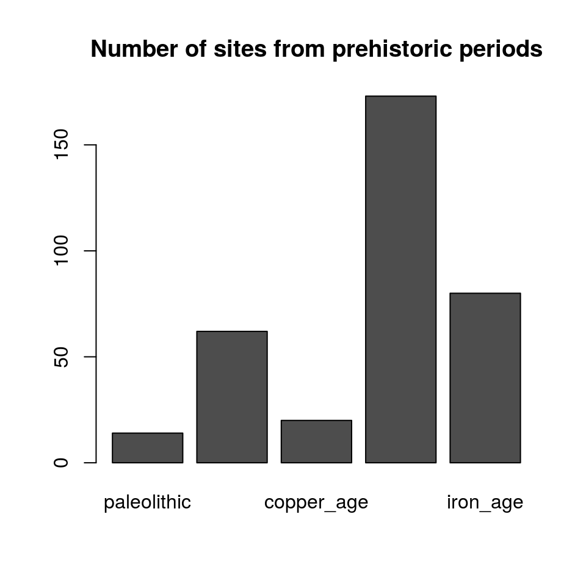

```r
barplot(cbind(
    paleolithic = sum(prehist$palaeolithic),
    neolithic = sum(prehist$neolithic),
    copper_age = sum(prehist$copper.age),
    bronze_age = sum(prehist$bronze.age),
    iron_age = sum(prehist$iron.age)
),
main = "Number of sites from prehistoric periods"
)
```

## at last: something to see

**Exercise:**

1. Plot the different numbers of site types.
2. Which way do you chose? Why? What other possibilities are there?

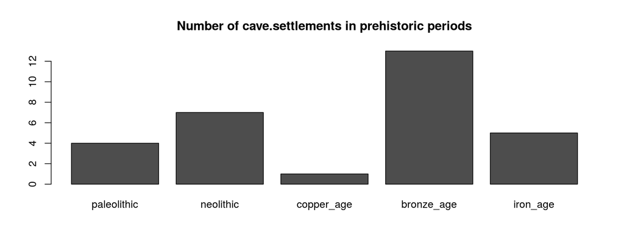

## at last: something to see – GGPLOT2

For the modern way we need to transform the data first from the a wide to a long format. Infos can be found e.g., [here](http://seananderson.ca/2013/10/19/reshape.html) or Wickham (2007) or Wickham (2014). In the case of wide data there is a column for each variable.

Let's first take care of the data structure. We want to investigate the amount of different sity types per period.

```r
types.per.period <- data.frame(palaeolithic = 0,
                               neolithic = 0,
                               copper.age = 0,
                               bronze.age = 0,
                               iron.age = 0
                               )
names(prehist)
```

```
##  [1] "Site.Name"       "settlement"      "open.settlement"
##  [4] "cave.settlement" "tell.settlement" "mound"
##  [7] "fortification"   "court"           "depot"
## [10] "cult.complex"    "mine"            "chruch"
## [13] "temple"          "villa.rustica"   "monastery"
## [16] "cemetery"        "necropolis"      "tumulus"
## [19] "palaeolithic"    "neolithic"       "copper.age"
## [22] "bronze.age"      "iron.age"        "xUTM"
## [25] "yUTM"
```

## at last: something to see – GGPLOT2

Data crunching

```r
library(magrittr); library(dplyr)
for (i in 3:18) {
    j <- i-2
    types.per.period[j,] <- prehist %>%
        filter(.[i] == 1) %>%
        summarise(paleolithic = sum(palaeolithic),
                  neolithic = sum(neolithic),
                  copper.age = sum(copper.age),
                  bronze.age = sum(bronze.age),
                  iron.age = sum(iron.age)
                  )
}

#str(types.per.period)
types.per.period$type <- names(prehist)[3:18]
types.per.period
```

```
##    palaeolithic neolithic copper.age bronze.age iron.age            type
## 1             2        10          1         57        9 open.settlement
## 2             4         7          1         13        5 cave.settlement
## 3             0         5          0          6        3 tell.settlement
## 4             0         0          0          1        0           mound
## 5             2         5          4         28       20   fortification
## 6             0         0          0          0        0           court
## 7             0         0          0          0        0           depot
## 8             0         0          0          0        1    cult.complex
## 9             0         1          0          2        4            mine
## 10            0         1          0          1        1          chruch
## 11            0         0          0          0        1          temple
## 12            0         0          0          0        0   villa.rustica
## 13            0         0          0          0        2       monastery
## 14            0         2          0         12        0        cemetery
## 15            1         4          2         10        9      necropolis
## 16            1         3          0         27        1         tumulus
```

## at last: something to see – GGPLOT2

This was again just data crunching/selection. Now, we change the data from wide to long format using the `reshape2` package.

```r
library(reshape2)
types2 <- melt(types.per.period, id.vars = c("type"))
str(types2)
```

```
## 'data.frame':    80 obs. of  3 variables:
##  $ type    : chr  "open.settlement" "cave.settlement" "tell.settlement" "mound" ...
##  $ variable: Factor w/ 5 levels "palaeolithic",..: 1 1 1 1 1 1 1 1 1 1 ...
##  $ value   : num  2 4 0 0 2 0 0 0 0 0 ...
```

```r
head(types2, 3)
```

```
##              type     variable value
## 1 open.settlement palaeolithic     2
## 2 cave.settlement palaeolithic     4
## 3 tell.settlement palaeolithic     0
```

**Question:** Do you see the difference? Describe the data new structure.

## at last: something to see – GGPLOT2

From this point on it is very easy and effortless to produce informative plots. We use the `ggplot2` package for this. Examples and documentation can be found at http://docs.ggplot2.org/current/ or in the [manual](https://cran.r-project.org/web/packages/ggplot2/ggplot2.pdf) or in Wickham (2009) as well as Zuur et al. (2009) (for the last on check this [link](http://www.cookbook-r.com/Graphs/)).

`ggplot2` package is build on the ideas of "Grammar of graphics". More information about this broad topic can be found in Wilkinson (2005).

`ggplot2` expects "tidy" data. To get to know what this exactly is, look at Wickham (2014).

## at last: something to see – GGPLOT2

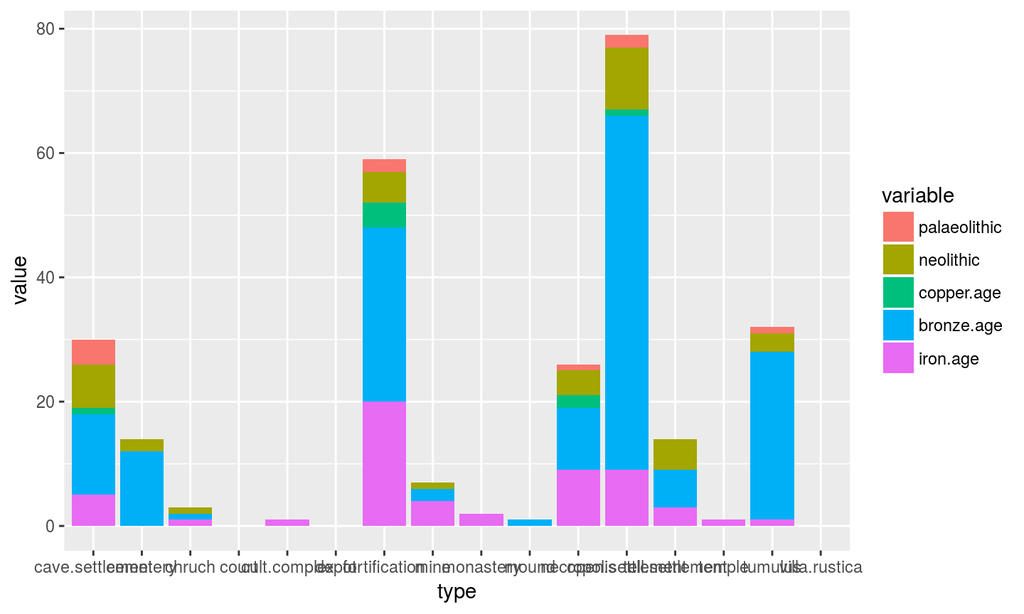

```r
library(ggplot2)
ggplot(types2, aes(x=type,y=value, fill=variable)) +
    geom_bar(stat="identity")
```

## at last: something to see – GGPLOT2

**Exercises**

1. Check the help of ggplot and reference pages on the internet to:
   - change the theme of the plot; Don't know what a "theme" is? Check help!
   - reorder the x-axis.
   - give a title
   - change the direction of x-labels to make them readable
2. Create a facet plot differentiated by period.

In the end it might look like this and this…

## at last: something to see – GGPLOT2

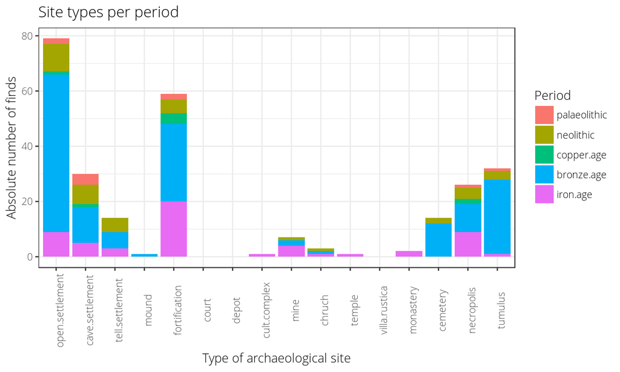

## at last: something to see – GGPLOT2

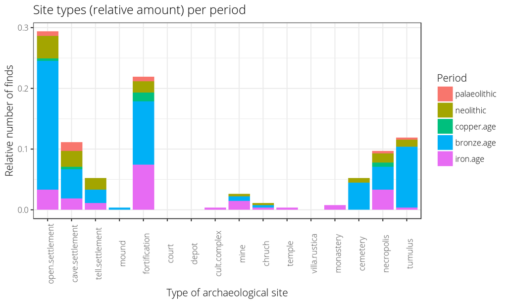

## at last: something to see – GGPLOT2

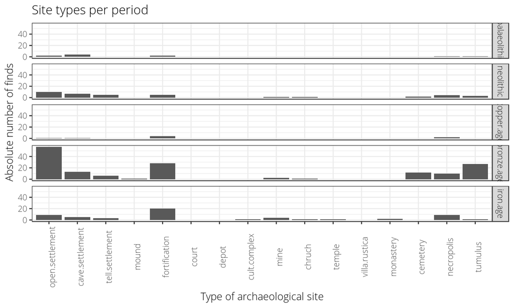

## at last: something to see – GGPLOT2

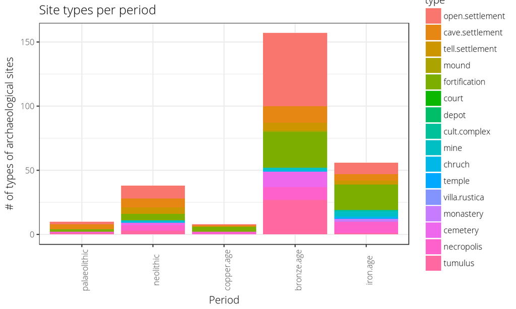

## at last: something to see – GGPLOT2

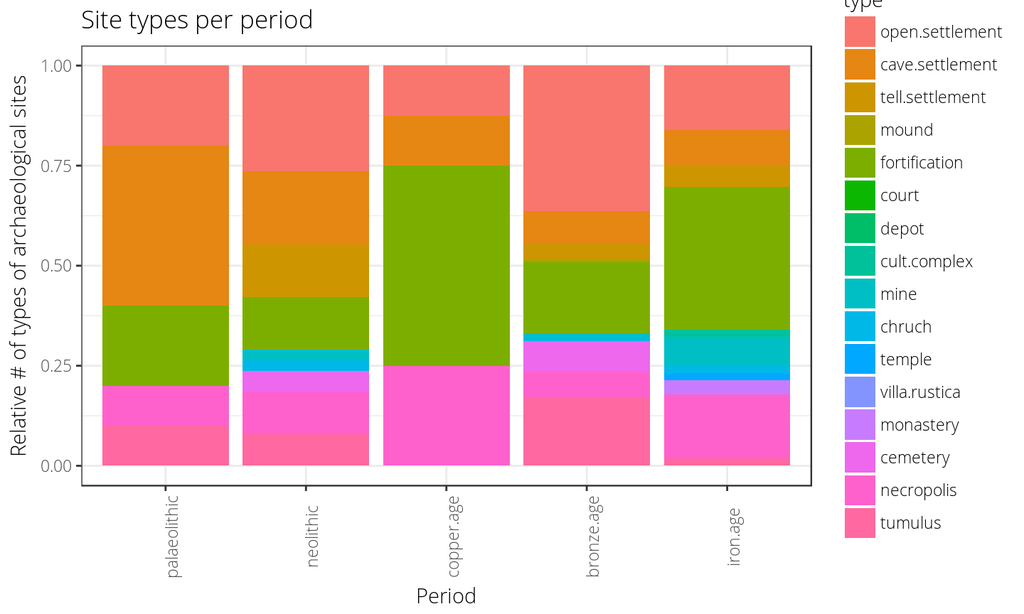

## References

Wickham, H., 2009. *Ggplot2: Elegant Graphics for Data Analysis*, New York: Springer.

Wickham, H., 2007. Reshaping Data with the reshape Package., 21(12). Available at: http://www.jstatsoft.org/article/view/v021i12 [Accessed November 30, 2015].

Wickham, H., 2014. Tidy data. *The Journal of Statistical Software*, 59(10). Available at: http://www.jstatsoft.org/v59/i10/.

Wilkinson, L., 2005. *The grammar of graphics* 2nd ed., New York: Springer.

Zuur, A.F., Ieno, E.N. & Meesters, E., 2009. *A Beginner’s Guide to R* 1st ed., Springer.